# Notes on survey analysis

João Miguel Alves

April 30, 2022

# Sample Stratification

We start by stratifying the sample according to notification habits, based on the answers provided in questions 8 and 9. We have defined 3 groups as follows:

```r
strata.table <- as.data.frame(
  cbind(freq = table(ds$Stratum),
        prop = round(prop.table(table(ds$Stratum)) * 100, 1)
  ))

strata.table %>%
  kableExtra::kbl() %>%
   kable_classic(full_width = F, html_font = "Cambria")
```

|  | freq | prop |
| --- | --- | --- |
| 1.Never notified | 117 | 53.9 |
| 2.Doesn’t usually notify | 58 | 26.7 |
| 3.Usually notifies | 42 | 19.4 |

# Analysis of Variance (ANOVA-PCA)

We want to evaluate how different these 3 groups are regarding their answers to the questionnaire. However, as we have 35 questions to evaluate, we start by performing a dimensionality reduction with Principal Components Analysis (PCA). From here, we perform an Analysis of Variance (ANOVA) to evaluate the differences among the groups.

*Note: we opt to use a parametric test such as ANOVA, considering that PCA results in continuous variables for which we can assume normality.*

```r
# Take answers for questions 1 to 35. Execute PCA analysis and show summary.
ds.pca <- ds[12:46]
pca <- prcomp(ds.pca, scale = FALSE)
summary(pca)
```

```
## Importance of components:
##                           PC1     PC2     PC3     PC4     PC5     PC6     PC7
## Standard deviation     2.8864 1.80115 1.73688 1.51073 1.46339 1.35204 1.29936
## Proportion of Variance 0.2036 0.07929 0.07373 0.05578 0.05234 0.04468 0.04126
## Cumulative Proportion  0.2036 0.28291 0.35664 0.41242 0.46475 0.50943 0.55069
##                            PC8     PC9    PC10    PC11    PC12    PC13    PC14
## Standard deviation     1.25556 1.18065 1.14513 1.12888 1.05972 1.04623 0.99653
## Proportion of Variance 0.03853 0.03407 0.03205 0.03115 0.02745 0.02675 0.02427
## Cumulative Proportion  0.58922 0.62329 0.65534 0.68649 0.71393 0.74068 0.76495
##                           PC15    PC16    PC17    PC18    PC19    PC20    PC21
## Standard deviation     0.95327 0.92163 0.91919 0.89697 0.83696 0.78237 0.76294
## Proportion of Variance 0.02221 0.02076 0.02065 0.01966 0.01712 0.01496 0.01423
## Cumulative Proportion  0.78716 0.80792 0.82857 0.84824 0.86536 0.88032 0.89454
##                           PC22    PC23    PC24   PC25    PC26    PC27   PC28
## Standard deviation     0.73247 0.70555 0.69432 0.6617 0.65143 0.64565 0.5829
## Proportion of Variance 0.01311 0.01217 0.01178 0.0107 0.01037 0.01019 0.0083
## Cumulative Proportion  0.90766 0.91982 0.93160 0.9423 0.95268 0.96287 0.9712
##                           PC29    PC30   PC31   PC32    PC33    PC34    PC35
## Standard deviation     0.53649 0.50808 0.4614 0.3836 0.35924 0.28977 0.24612
## Proportion of Variance 0.00703 0.00631 0.0052 0.0036 0.00315 0.00205 0.00148
## Cumulative Proportion  0.97820 0.98451 0.9897 0.9933 0.99647 0.99852 1.00000
```

It can be noted that:

- both *Standard deviation* and *Proportion of Variance* for each component are progressively smaller, showing that each component explains less sample variability than the previous.
- *Cumulative Proportion* of Variance accumulates to 1, showing that all components combined fully explain sample variability.

For a cleaner interpretation, let’s evaluate how much sample variance is explained by the first 4 components.

```r
for (i in 1:4){
  print(paste0("PC", i, " variance: ", summary(pca)$importance[2,i],
               " | cumulative: ", summary(pca)$importance[3,i]), quote = FALSE)
  }
```

```
## [1] PC1 variance: 0.20362 | cumulative: 0.20362
## [1] PC2 variance: 0.07929 | cumulative: 0.28291
## [1] PC3 variance: 0.07373 | cumulative: 0.35664
## [1] PC4 variance: 0.05578 | cumulative: 0.41242
```

It can be noted that:

- First component (PC1) explains 20.3% of sample variance
- Second component (PC2) explains 7.9% of sample variance
- The first 3 component combined explain a total of 35.6%, that is, more that 1/3 of sample variance

## All groups

Let’s execute ANOVA on the different groups, assuming only the first 3 components.

```r
#' Prepare a dataset with strata and PCs 1 to 3, for analysis. Also prepare subsets for each stratum.
ds.test <- data.frame(strata = ds$Stratum,
                      pc1 = pca$x[,1],
                      pc2 = pca$x[,2],
                      pc3 = pca$x[,3])

ds.test.stratum1 <- subset(ds.test, strata == "1.Never notified")
ds.test.stratum2 <- subset(ds.test, strata == "2.Doesn't usually notify")
ds.test.stratum3 <- subset(ds.test, strata == "3.Usually notifies")
```

```r
#' Test for all 3 strata simultaneously
aov.test.all <- aov(pc1 + pc2 + pc3 ~ strata,
                    data = ds.test)
summary(aov.test.all)
```

```
##              Df Sum Sq Mean Sq F value   Pr(>F)
## strata        2  226.5  113.23   8.283 0.000343 ***
## Residuals   214 2925.5   13.67
## ---
## Signif. codes:  0 '***' 0.001 '**' 0.01 '*' 0.05 '.' 0.1 ' ' 1
```

The p-values of 0.000343 (that is, below alpha 0.05) rejects the null hypothesis of all groups’ means being equal. Therefore, we must conclude that **there are statistically significant differences among the 3 groups** (p < 0.001). That is, the 3 groups initially defined are not similar between themselves.

Let’s now perform the analysis for only 2 groups at a time.

## Group 1 vs 2

```r
#' Test pairs of strata: 1 vs 2 (exclude 3)
#'   - 1.Never notified
#'   - 2.Doesn't usually notify
aov.test.12 <- aov(pc1 + pc2 + pc3 ~ strata,
                   data = subset(ds.test, strata != "3.Usually notifies"))
summary(aov.test.12)
```

```
##              Df Sum Sq Mean Sq F value Pr(>F)
## strata        1    2.4   2.365   0.167  0.683
## Residuals   173 2451.8  14.172
```

In this case, the p-values does not rejects null hypothesis. We conclude that **there is no significant difference between strata 1 and 2** (p = 0.683). That is, users who never notified (group 1) respond similarly to those who don’t usually notify (group 2).

## Group 1 vs 3

```r
#' Test pairs of strata: 1 vs 3 (exclude 2)
#'   - 1.Never notified
#'   - 3.Usually notifies
aov.test.13 <- aov(pc1 + pc2 + pc3 ~ strata,
                   data = subset(ds.test, strata != "2.Doesn't usually notify"))
summary(aov.test.13)
```

```
##              Df Sum Sq Mean Sq F value   Pr(>F)
## strata        1  191.7   191.7   13.79 0.000283 ***
## Residuals   157 2181.6    13.9
## ---
## Signif. codes:  0 '***' 0.001 '**' 0.01 '*' 0.05 '.' 0.1 ' ' 1
```

Here, the p-values rejects the null hypothesis, meaning that these groups are indeed different. We conclude that **there is a statistical significant difference between strata 1 and 3** (p < 0.001). That is, Non-notifiers (group 1) and Regular-notifiers (group 3) respond differently.

## Group 2 vs 3

```r
#' Test pairs of strata: 2 vs 3 (exclude 1)
#'   - 2.Doesn't usually notify
#'   - 3.Usually notifies
aov.test.23 <- aov(pc1+pc2+pc3 ~ strata,
                   data = subset(ds.test, strata != "1.Never notified"))
summary(aov.test.23)
```

```
##             Df Sum Sq Mean Sq F value   Pr(>F)
## strata       1  182.5  182.52   14.69 0.000224 ***
## Residuals   98 1217.5   12.42
## ---
## Signif. codes:  0 '***' 0.001 '**' 0.01 '*' 0.05 '.' 0.1 ' ' 1
```

Also in this case, the p-values rejects null hypothesis showing that these groups are different. We conclude that **there is a statistical significant difference between strata 2 and 3** (p < 0.001). That is, Infrequent-notifiers (group 2) and Regular-notifiers (group 3) respond differently.

## Conclusion from ANOVA-PCA

From this analysis, we conclude that Non-notifiers (group 1) and Infrequent-notifiers (group 2) responded similarly to the questionnaire (p=0.683). However, Frequent-notifiers (group 3) present respond significantly different answers from the other 2 groups (p<0.001)

Based on this analysis, we can assume that it is meaningless to discriminate groups 1 and 2, for which we can treat these as a single group.

# Comparing questionnaire results

We proceed with the analysis to questionnaire results for all 35 questions. Based on previous analysis, we assume 2 different groups:

- Non-regular notifiers (previously groups *1.Never notified* and *2.Doesn’t usually notify*)
- Regular notifiers (previously group *3.Usually notifies*)

We compare responses of both groups to each question with Mann–Whitney U test, considering that Likert scale values are ordinal. P-values < 0.05 suggest that both groups have different attitudes towards the question asked.

*Note: here we opt to use a non-parametric test such as Mann–Whitney U test, considering that a 5-point likert scale is not a continuous variable but rather an ordinal categorical one. Nonetheless, this interpretation is not universal, with some researchers opting to treat Likert scales as continuous variables.*

From the table below it can be noted that for question “Q01. I am familiar with the Portuguese Pharmacovigilance System.” both groups have different attitudes toward this topic (p < 0.001)

In contrast, question “Q07. Pharmacovigilance is an important activity in the drug life cycle.” appears to trigger similar responses between both groups (p = 0.634).

```r
# Define questions to analyse
questions <- 1:35

# Prepare summary statistics for groups 1 and 2 combined
groups_12 <- subset(ds, ds$Stratum != "3.Usually notifies")

groups_12.stats <- data.frame(
  median = apply(groups_12[questions+11], MARGIN = 2, median),
  q25    = apply(groups_12[questions+11], MARGIN = 2, FUN = function(x){quantile(x, probs = .25)}),
  q75    = apply(groups_12[questions+11], MARGIN = 2, FUN = function(x){quantile(x, probs = .75)})
)

groups_12.stats$summary <-
  paste0(groups_12.stats$median, " [",
         groups_12.stats$q25, ", ",
         groups_12.stats$q75, "]")

# Prepare summary statistics for group 3
group_3   <- subset(ds, ds$Stratum == "3.Usually notifies")

group_3.stats <- data.frame(
  median = apply(group_3[questions+11], MARGIN = 2, median),
  q25    = apply(group_3[questions+11], MARGIN = 2, FUN = function(x){quantile(x, probs = .25)}),
  q75    = apply(group_3[questions+11], MARGIN = 2, FUN = function(x){quantile(x, probs = .75)})
)

group_3.stats$summary <-
  paste0(group_3.stats$median, " [",
         group_3.stats$q25, ", ",
         group_3.stats$q75, "]")

# Set new stratum variable with only 2 strata
ds$Stratum2 <- ifelse(ds$Stratum == "3.Usually notifies", "Regular notifiers", "Non-regular notifiers")


# Calculate p-values Mann-Whitney U test for each questions, comparing both groups
p.values <- sapply(seq_along(questions)+11, FUN = function(x){
  wilcox.test(ds[[x]] ~ ds$Stratum2)$p.value
  })
bonferroni <- p.values * 35
bonferroni <- ifelse(bonferroni > 1, 1, bonferroni)
bonferroni <- ifelse(bonferroni < 0.001, "< 0.001", format(round(bonferroni, 3), nsmall = 3))
p.values <- ifelse(p.values < 0.001, "< 0.001", format(round(p.values, 3), nsmall = 3))

# Aggregate results in a single table
result <- data.frame(
  Question = names(ds)[questions+11],
  Groups_12 = groups_12.stats$summary,
  Group_3 = group_3.stats$summary,
  P_value = p.values,
  Bonferroni = bonferroni
)

adjusted.names <- c(
  "Question",
  "Non-regular notifiers (median, [IQR]) n=175",
  "Regular notifiers (median, [IQR]) n=42",
  "Mann-Whitney U test",
  "Bonferroni correction"
)

result %>%
  kableExtra::kbl(
    align = c("l", "c", "c", "c", "c"),
    col.names = adjusted.names,
    caption =
      paste("Median, IQR and Mann-Whitney U test p-values between groups for each question.",
      "All participants from each group responded to all 35 questions.",
      # "Non-regular notifiers: n=175. Regular notifiers: n=42.",
      "With Bonferroni's correction, a p-value < 0.001 indicates a significant difference.",
      "Likert scale: 1 = Strongly disagree, 2 = Disagree,  3 = Neither,  4 = Agree,  5 = Strongly Agree."
      )
    ) %>%
  kableExtra::kable_styling(bootstrap_options = c("striped", "hover", "condensed")) %>%
  kableExtra:: kable_classic(full_width = T, html_font = "Cambria")
```

Median, IQR and Mann-Whitney U test p-values between groups for each question. All participants from each group responded to all 35 questions. With Bonferroni’s correction, a p-value < 0.001 indicates a significant difference. Likert scale: 1 = Strongly disagree, 2 = Disagree, 3 = Neither, 4 = Agree, 5 = Strongly Agree.

| Question | Non-regular notifiers (median, [IQR]) n=175 | Regular notifiers (median, [IQR]) n=42 | Mann-Whitney U test | Bonferroni correction |
| --- | --- | --- | --- | --- |
| Q01. I am familiar with the Portuguese Pharmacovigilance System. | 3 [3, 4] | 4 [3, 5] | < 0.001 | 0.022 |
| Q02. I am familiar with the existence of the Porto Pharmacovigilance Centre. | 3 [3, 5] | 4 [3, 5] | 0.170 | 1.000 |
| Q03. I am familiar with the Portal RAM for reporting suspected ADR. | 3 [2.5, 4] | 4 [3, 5] | < 0.001 | 0.007 |
| Q04. I am familiar with the different means for reporting suspected ADR. | 3 [2, 4] | 4 [3, 4] | 0.003 | 0.095 |
| Q05. I am familiar with the update of the concept of ADR. | 3 [2, 4] | 4 [3, 5] | < 0.001 | 0.010 |
| Q06. I am aware that users can report suspected ADR directly to the Portuguese Pharmacovigilance System. | 4 [3, 5] | 5 [4, 5] | 0.059 | 1.000 |
| Q07. Pharmacovigilance is an important activity in the drug life cycle. | 5 [5, 5] | 5 [5, 5] | 0.634 | 1.000 |
| Q08. Pharmacovigilance is a minor activity in the care practice universe of the Community Pharmacist. | 1 [1, 1] | 1 [1, 2] | 0.043 | 1.000 |
| Q09. Reporting a suspected ADR is a simple and intuitive process. | 3 [3, 4] | 4 [3, 4] | 0.012 | 0.410 |
| Q10. Reporting a suspected ADR is a fast process. | 3 [2, 4] | 3 [3, 4] | 0.039 | 1.000 |
| Q11. I have a habit of reading the pharmacovigilance bulletin edited by INFARMED. | 3 [2, 4] | 3 [3, 4] | 0.059 | 1.000 |
| Q12. I am familiar with my deontological and ethical obligations to report suspected ADR. | 4 [4, 5] | 5 [4.25, 5] | 0.002 | 0.082 |
| Q13. I am careful to question the patient about ADR in my professional activity, assuming a proactive position in this issue. | 4 [3, 4] | 4 [4, 5] | < 0.001 | < 0.001 |
| Q14. As a health professional, I have enough knowledge to identify a suspected ADR. | 4 [3, 4] | 5 [4, 5] | < 0.001 | 0.002 |
| Q15. In my daily practice of interaction with the patient, I can easily detect suspected ADR. | 3 [3, 4] | 4 [3, 4] | 0.078 | 1.000 |
| Q16. I believe that the report suspected ADR to the Porto Pharmacovigilance System may impact the patient’s quality of life at the personal, social, and/or economic level. | 4 [3, 5] | 5 [4, 5] | 0.016 | 0.573 |
| Q17. I fear that the reporter`s confidentiality may be broken during the ADR report process. | 1 [1, 2] | 1 [1, 2] | 0.820 | 1.000 |
| Q18. I fear that the patient´s anonymity may be broken during the ADR report process. | 1 [1, 2] | 1.5 [1, 2] | 0.588 | 1.000 |
| Q19. I fear that the adverse reaction may not be due to the suspected drug. | 3 [3, 4] | 3 [3, 4] | 0.112 | 1.000 |
| Q20. I only report an ADR if I am certain that it is related to the use of a particular drug. | 4 [3, 5] | 3 [2, 4.75] | 0.002 | 0.064 |
| Q21. It is almost impossible to determine if a drug is responsible for a certain ADR. | 2 [2, 3] | 2 [1, 3] | 0.066 | 1.000 |
| Q22. When I know that a new drug has been introduced in the market, I am careful to read the SmPC on information about ADR or undesirable effects. | 4 [3, 5] | 4 [3, 5] | 0.125 | 1.000 |
| Q23. I am reluctant to be judged by the report of a suspected ADR. | 2 [1, 3] | 1 [1, 2] | 0.001 | 0.037 |
| Q24. I am reluctant to admit that it may have contributed to the occurrence of ADR in the patient. | 2 [1, 3] | 1 [1, 3] | 0.103 | 1.000 |
| Q25. The report of a single case is relevant to the knowledge of the safety profile of that drug. | 4 [3, 5] | 4 [3, 5] | 0.452 | 1.000 |
| Q26. When it comes to an ADR described in the SmPC, I find it important to report. | 3 [2, 4] | 4 [3, 5] | 0.056 | 1.000 |
| Q27. I find it important to report when it comes to an unexpected ADR (not described in the SmPC). | 5 [5, 5] | 5 [5, 5] | 0.031 | 1.000 |
| Q28. When it comes to a frequent ADR, I find it important to report. | 4 [2, 5] | 4 [3, 5] | 0.879 | 1.000 |
| Q29. When it comes to a non−severe ADR, I find it important to report. | 4 [3, 5] | 5 [4, 5] | 0.066 | 1.000 |
| Q30. I report suspected ADR for the clinical impact that this information has on other users taking that drug. | 4 [3, 5] | 5 [4, 5] | 0.043 | 1.000 |
| Q31. I believe that the spontaneous report of suspected ADR has regulatory consequences on the use of that drug. | 4 [3, 5] | 5 [4, 5] | 0.004 | 0.139 |
| Q32. I report suspected ADR for the need to share experiences of my professional practice. | 3 [2, 4] | 3 [3, 5] | 0.019 | 0.665 |
| Q33. When it comes to a recent marketing authorization drug (<2 years), I have additional concerns in the report of suspected ADR. | 4 [3, 5] | 5 [4, 5] | 0.006 | 0.203 |
| Q34. The time taken to report is the determining factor not to report, or not report as much as I wish, the suspected ADR that I know. | 3 [3, 4] | 3 [1.25, 4] | 0.042 | 1.000 |
| Q35. In view of a suspected ADR, I contact the pharmaceutical industry (e.g. Medical Sales Representatives). | 3 [2, 4] | 3 [2, 4] | 0.650 | 1.000 |

# Association test for PE, CP, AS

From previous analysis, we pick questions with statistically significant difference regarding notification habits and evaluated further regarding:

- PE: Professional Experience
- CP: Specialist in Community Pharmacy
- AS: Academic Studies

To determine whether there is a statistically significant association between these variables and questions’ scores, we use Pearson’s Chi-squared test.

```r
# Define questions and variables to analyse
questions <-
  c("Q01. I am familiar with the Portuguese Pharmacovigilance System."
    , "Q03. I am familiar with the Portal RAM for reporting suspected ADR."
    , "Q05. I am familiar with the update of the concept of ADR."
    , "Q13. I am careful to question the patient about ADR in my professional activity, assuming a proactive position in this issue."
    , "Q14. As a health professional, I have enough knowledge to identify a suspected ADR."
    , "Q23. I am reluctant to be judged by the report of a suspected ADR."
    )

variables <-
  c("Professional Experience"
    , "Specialization in Community Pharmacy"
    , "Academic Degree"
    )

# Define combinations of 'variables' vs 'questions'
combinations <- expand.grid(variables, questions, stringsAsFactors = FALSE)
names(combinations) <- c("variable", "question")
combinations$p.value <- NA

# Compute p.value for Chi.square test
for (i in 1:nrow(combinations)){
  chi <-
    chisq.test(ds[[combinations$variable[i]]],
               ds[[combinations$question[i]]])
  combinations$p.value[i] <- chi$p.value
}

# Aggregate values in a single table
table3 <- reshape2::dcast(data = combinations,
     formula = question ~ variable,
     fun.aggregate = function(x){sprintf("%.3f", sum(x))},
     value.var = 'p.value')
names(table3)[1] <- "Question"


# Print table
table3 %>%
  kableExtra::kbl(
    align = c("l", "c", "c","c"),
    caption = paste("P-values for Pearson's Chi-squared test")
    ) %>%
  kableExtra::kable_styling(bootstrap_options = c("striped", "hover", "condensed")) %>%
  kableExtra:: kable_classic(full_width = T, html_font = "Cambria")
```

P-values for Pearson’s Chi-squared test

| Question | Academic Degree | Professional Experience | Specialization in Community Pharmacy |
| --- | --- | --- | --- |
| Q01. I am familiar with the Portuguese Pharmacovigilance System. | 0.141 | 0.089 | 0.068 |
| Q03. I am familiar with the Portal RAM for reporting suspected ADR. | 0.891 | 0.551 | 0.146 |
| Q05. I am familiar with the update of the concept of ADR. | 0.106 | 0.008 | 0.076 |
| Q13. I am careful to question the patient about ADR in my professional activity, assuming a proactive position in this issue. | 0.992 | 0.826 | 0.546 |
| Q14. As a health professional, I have enough knowledge to identify a suspected ADR. | 0.399 | 0.215 | 0.500 |
| Q23. I am reluctant to be judged by the report of a suspected ADR. | 0.547 | 0.532 | 0.265 |

To a significance level of 0.05, we conclude that there is a statistically significant association between the years of professional experience and the answers to question 5 “I am familiar with the update of the concept of ADR” (p = 0.008, χ2 = 32.888).

```r
Professional.Experience <- ds[["Professional Experience"]]
Question05 <- ds[["Q05. I am familiar with the update of the concept of ADR."]]
chisq.test(Professional.Experience, Question05)
```

```
##
##  Pearson's Chi-squared test
##
## data:  Professional.Experience and Question05
## X-squared = 32.888, df = 16, p-value = 0.007646
```

## Contingency Table and Plot

Contingency Table and barplot on association between years of professional experience and answers to question 5 “I am familiar with the update of the concept of ADR”.

```r
var.x <- as.factor(ds$`Professional Experience`)
var.y <- as.factor(ds$`Q05. I am familiar with the update of the concept of ADR.`)
levels(var.y) <- c("1. Strongly disagree"
                   , "2. Disagree"
                   , "3. Neutral"
                   , "4. Agree"
                   , "5. Strongly Agree")

ds.to.plot <- data.frame(Professional.Experience = var.x,
                Scale = var.y)

# Print contingency table in proportion, calculated per row
print(round(prop.table(table(ds.to.plot[,2:1]), margin = 2) * 100, 2))
```

```
##                       Professional.Experience
## Scale                  < 1 year 1-3 years 4-10 years 11-20 years > 20 years
##   1. Strongly disagree     0.00      0.00      14.81        7.79       1.96
##   2. Disagree             16.67     17.39      12.96       19.48      19.61
##   3. Neutral              25.00     17.39      46.30       27.27      29.41
##   4. Agree                50.00     52.17      18.52       20.78      31.37
##   5. Strongly Agree        8.33     13.04       7.41       24.68      17.65
```

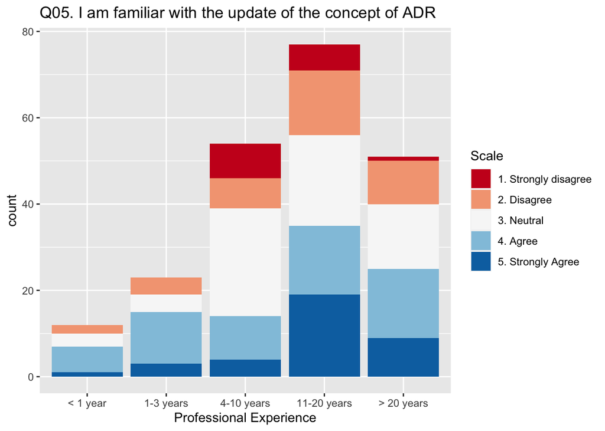

```r
library(ggplot2)

colors <- RColorBrewer::brewer.pal(n = 5, name = "RdBu")
ggplot(ds.to.plot, aes(x = Professional.Experience, fill = Scale)) +
  geom_bar() +
  scale_fill_manual(values = colors) +
  ggtitle("Q05. I am familiar with the update of the concept of ADR") +
  xlab("Professional Experience") +
  ylab("count")
```

## Boxplot

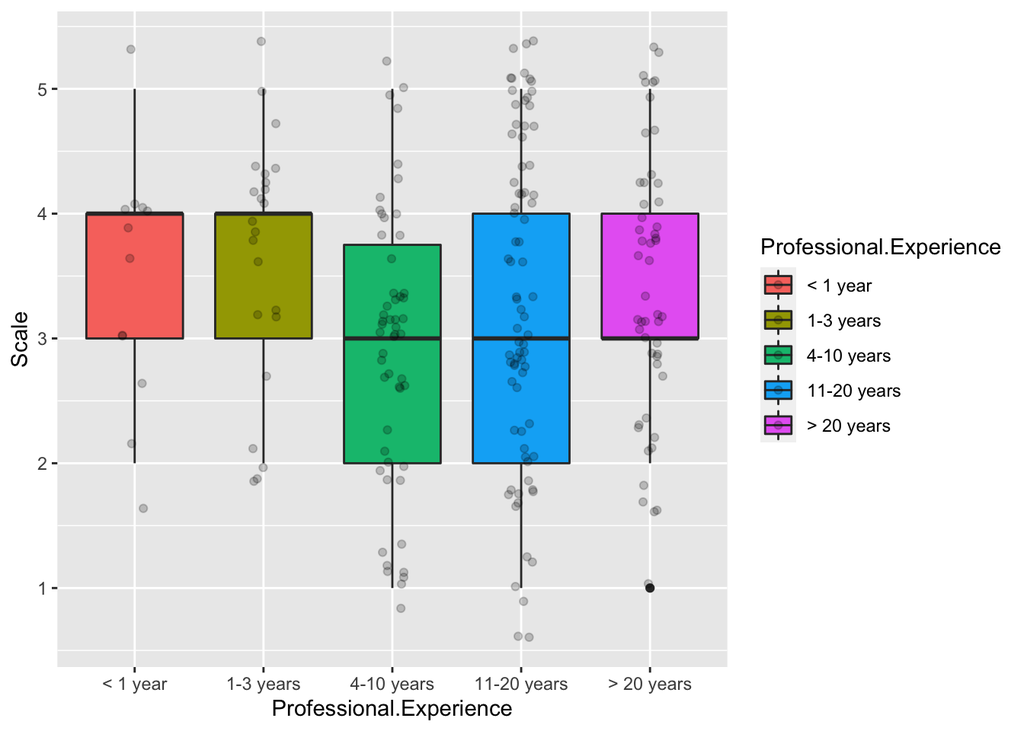

```r
ds.to.plot$Scale <- as.integer(ds.to.plot$Scale)
ggplot(ds.to.plot, aes(x = Professional.Experience, y = Scale, fill = Professional.Experience)) +
  geom_boxplot(notch = FALSE) + geom_jitter(width=0.1,alpha=0.2)
```

## Violin Plot

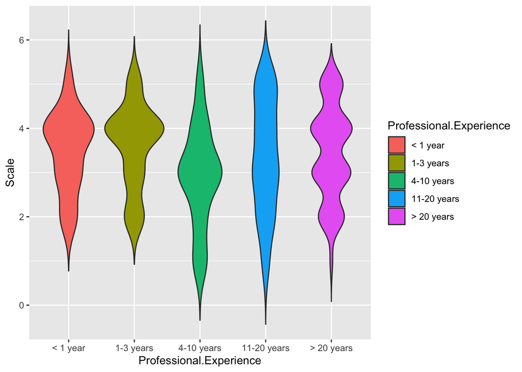

```r
ggplot(ds.to.plot, aes(x = Professional.Experience, y = Scale, fill = Professional.Experience)) +
  geom_violin(trim=FALSE)
```